# Tropical Cyclone Dikeledi (2025): Rapid Report

Lincole Jiang, Majd Abid, Lawrence Chillrud, G. Brooke Anderson, Robbie M. Parks

2026-04-16

## Summary

**Data status:** Provisional — not yet reanalyzed (US-PROVISIONAL)

*Tropical Cyclone Dikeledi* (2025) was active from 2024-12-28 18:00:00 to 2025-01-20 UTC. Based on IBTrACS data obtained 04/16/2026, 6,365,155 people experienced tropical cyclone-force (>= 17.49 m/s) winds and 810,249.5 people experienced hurricane-force (>= 32.90 m/s) winds across Mozambique, Madagascar. No areas experienced Category 5 winds.

Table 1: Population exposed by country and storm intensity

| Country | Population exposed (tropical cyclone-force) | Population exposed (hurricane-force) |
| --- | --- | --- |
| Mozambique | 4,985,672 | 810,250 |
| Madagascar | 1,379,483 | 0 |

When accounting for total population, the table below shows the percentage of each country’s population exposed.

Table 2: Percentage of total population exposed by country and storm intensity

| Country | % Population exposed (tropical cyclone-force) | % Population exposed (hurricane-force) |
| --- | --- | --- |
| Mozambique | 15.9 | 2.6 |
| Madagascar | 4.9 | 0.0 |

The spatial extent of the impacts is illustrated in Figure 1, which maps exposure by wind intensity threshold at the second administrative unit (ADM2) level along with the storm track of Dikeledi.

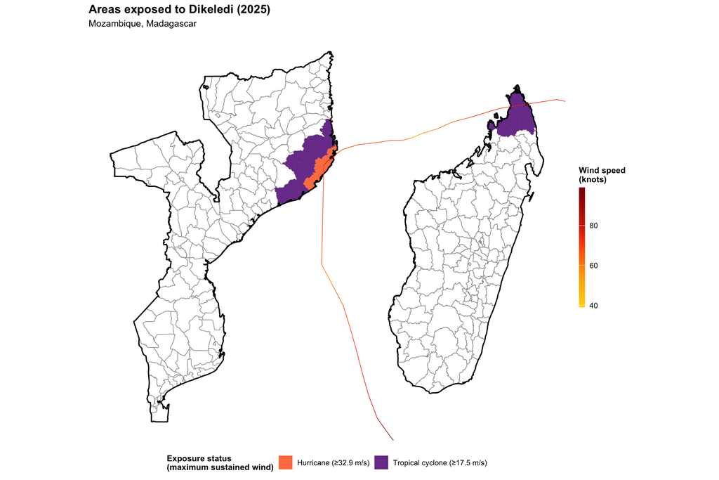

Figure 1: Spatial distribution of exposure

## Characterizing exposed areas

Figure 2 shows the distribution of relative deprivation (measured by population-weighted GRDI, aggregated to ADM2 level) and population for each exposed area, categorized by exposure status.

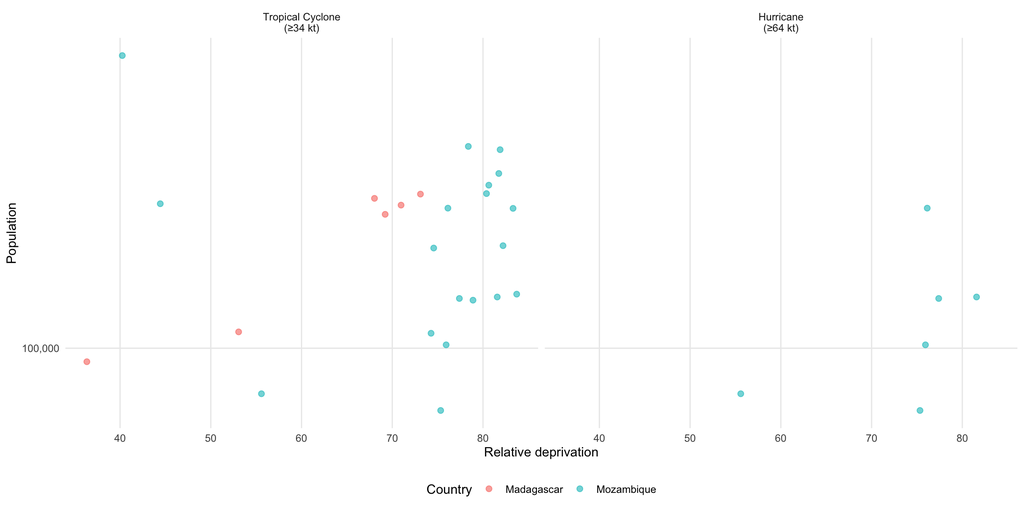

Figure 2: Socioeconomic and population distribution of exposed areas

Furthermore, we list the top areas affected (categorized by exposure status) with the most population:

|  | Area | Country | Population | Relative deprivation |
| --- | --- | --- | --- | --- |
| 1 | Cidade De Nampula | Mozambique | 875,945 | Moderately high |
| 2 | Monapo | Mozambique | 446,585 | High |
| 3 | Mogovolas | Mozambique | 435,848 | High |
| 4 | Rapale | Mozambique | 365,373 | High |
| 5 | Moma | Mozambique | 335,021 | High |
| 6 | Memba | Mozambique | 314,746 | High |
| 7 | Vohemar | Madagascar | 313,540 | High |
| 8 | Ambilobe | Madagascar | 303,799 | High |
| 9 | Nacala | Mozambique | 291,931 | Moderately high |
| 10 | Antsiranana II | Madagascar | 288,939 | High |

[output cut: 15 more lines]

|  | Area | Country | Population | Relative deprivation |
| --- | --- | --- | --- | --- |
| 1 | Angoche | Mozambique | 282,539 | High |
| 2 | Liúpo | Mozambique | 146,199 | High |
| 3 | Mossuril | Mozambique | 144,614 | High |
| 4 | Larde | Mozambique | 102,534 | High |
| 5 | Ilha De Moçambique | Mozambique | 71,344 | High |
| 6 | Mogincual | Mozambique | 63,021 | High |

```
## *No areas experienced Category 5-force winds.*
```

- Note: GRDI relative deprivation values were classified into quartiles: 0–0.25 (low), 0.25–0.50 (moderately low), 0.50–0.75 (moderately high), 0.75–1.0 (high).